# Milestone 2

The overall goal of this milestone is to take all necessary steps to inspect the quality of your data. Begin by reading through this article on Exploratory Data Analysis (EDA):

https://towardsdatascience.com/exploratory-data-analysis-8fc1cb20fd15

Once you’ve read through this information, choose your data set and (at a minimum) complete the tasks listed in this file.

Start by reading the data into your notebook.

```python
import pandas
df = pandas.read_csv('north-transfer-station-solar-panels.csv')
df.head(872)
```

|  | Date | Inverter1 | Inverter2 | Inverter3 | Inverter4 |
| --- | --- | --- | --- | --- | --- |
| 0 | 2018-May-31 | 161.6 | 156.8 | 160.0 | 158.0 |
| 1 | 2018-May-30 | 221.9 | 218.8 | 221.2 | 221.0 |
| 2 | 2018-May-29 | 145.6 | 143.3 | 144.9 | 144.8 |
| 3 | 2018-May-28 | 187.0 | 184.3 | 185.9 | 184.6 |
| 4 | 2018-May-27 | 261.1 | 257.2 | 260.0 | 259.4 |
| ... | ... | ... | ... | ... | ... |
| 866 | 2016-Apr-17 | NaN | NaN | NaN | NaN |
| 867 | 2016-Apr-16 | NaN | NaN | NaN | NaN |
| 868 | 2016-Apr-15 | NaN | NaN | NaN | NaN |
| 869 | 2016-Apr-14 | NaN | NaN | NaN | NaN |
| 870 | 2016-Apr-13 | NaN | NaN | NaN | NaN |

871 rows × 5 columns

Why did you pick this data? Explain what you hope to learn from this data. Do you have a hunch about what this data will reveal? The answer to this question will be used in the Introduction section of the final report.

We picked this data because we want to learn more about the solar industry. We think this data will help us learn more about how well can the city of Seattle generate solar energy.

What is the population being represented by the data you’ve chosen? What is the total sample size?

Our data measure how the four selected solar panel inverters can help Seattle's North Transfer Station generate solar energy. There are 871 attempted collections for each inverter. However, not all attempts were successful.

Describe how the data was collected. For example, is this a random sample? Are sampling weights used with the data?

All data was collected by the inverter. No sampling methods & sampling weights were used.

Inspect the data. For example, inspect the first and last 10 rows.

```python
import pandas
df = pandas.read_csv('north-transfer-station-solar-panels.csv')
df.head(10)
```

|  | Date | Inverter1 | Inverter2 | Inverter3 | Inverter4 |
| --- | --- | --- | --- | --- | --- |
| 0 | 2018-May-31 | 161.6 | 156.8 | 160.0 | 158.0 |
| 1 | 2018-May-30 | 221.9 | 218.8 | 221.2 | 221.0 |
| 2 | 2018-May-29 | 145.6 | 143.3 | 144.9 | 144.8 |
| 3 | 2018-May-28 | 187.0 | 184.3 | 185.9 | 184.6 |
| 4 | 2018-May-27 | 261.1 | 257.2 | 260.0 | 259.4 |
| 5 | 2018-May-26 | 155.8 | 153.9 | 154.4 | 153.8 |
| 6 | 2018-May-25 | 152.9 | 150.4 | 152.7 | 152.4 |
| 7 | 2018-May-24 | 178.8 | 176.6 | 176.9 | 176.5 |
| 8 | 2018-May-23 | 256.5 | 251.0 | 255.6 | 253.8 |
| 9 | 2018-May-22 | 265.8 | 262.8 | 265.9 | 264.8 |

```python
import pandas
df = pandas.read_csv('north-transfer-station-solar-panels.csv')
df.tail(10)
```

|  | Date | Inverter1 | Inverter2 | Inverter3 | Inverter4 |
| --- | --- | --- | --- | --- | --- |
| 861 | 2016-Apr-22 | NaN | NaN | NaN | NaN |
| 862 | 2016-Apr-21 | NaN | NaN | 20.3 | 14.9 |
| 863 | 2016-Apr-20 | NaN | NaN | NaN | NaN |
| 864 | 2016-Apr-19 | NaN | NaN | NaN | NaN |
| 865 | 2016-Apr-18 | NaN | NaN | NaN | NaN |
| 866 | 2016-Apr-17 | NaN | NaN | NaN | NaN |
| 867 | 2016-Apr-16 | NaN | NaN | NaN | NaN |
| 868 | 2016-Apr-15 | NaN | NaN | NaN | NaN |
| 869 | 2016-Apr-14 | NaN | NaN | NaN | NaN |
| 870 | 2016-Apr-13 | NaN | NaN | NaN | NaN |

Provide a data dictionary, i.e. provide a description of the data elements and their corresponding values.

Please look for the dictionary after the second boxplot. Since there are some missing values, we thought it'd be best to build the dictionary with the clean data.

### Report on the quality of the data.

Are there rows with missing or inconsistent values? Are there any outliers or duplicate rows? If so, eliminate those rows from your data where appropriate. State how many rows were eliminated at this step. Consider some type of visual display such as a boxplot to determine any outliers. Include the rest of your work below.

There are some missing values. There are some rows with no values and other rows with values missing at certain columns. There are outlier but no duplicate rows. The unusable rows are eliminated using the procedures below. We started off with 871 rows. 154 rows were being removed for having missing or inconsistent values, bringing the total to 717. Five rows were subsequently removed for being outliers, bringing the total to 712.

```python
import pandas as pd
df = pd.read_csv('north-transfer-station-solar-panels.csv')
newdf=df.dropna(axis = 0, how ='any')
newdf
```

|  | Date | Inverter1 | Inverter2 | Inverter3 | Inverter4 |
| --- | --- | --- | --- | --- | --- |
| 0 | 2018-May-31 | 161.6 | 156.8 | 160.0 | 158.0 |
| 1 | 2018-May-30 | 221.9 | 218.8 | 221.2 | 221.0 |
| 2 | 2018-May-29 | 145.6 | 143.3 | 144.9 | 144.8 |
| 3 | 2018-May-28 | 187.0 | 184.3 | 185.9 | 184.6 |
| 4 | 2018-May-27 | 261.1 | 257.2 | 260.0 | 259.4 |
| ... | ... | ... | ... | ... | ... |
| 847 | 2016-Aug-06 | 166.6 | 159.9 | 163.8 | 140.3 |
| 848 | 2016-Aug-05 | 255.4 | 250.7 | 255.1 | 221.8 |
| 849 | 2016-Aug-04 | 257.8 | 254.3 | 257.3 | 225.4 |
| 850 | 2016-Aug-03 | 213.5 | 210.8 | 211.1 | 188.1 |
| 851 | 2016-Aug-02 | 1426.8 | 1398.0 | 1419.5 | 232.0 |

717 rows × 5 columns

cleaned the data by deleting collections dates that did not have a reading for all inverters

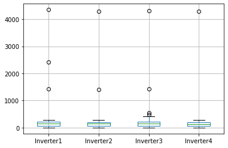

```python
import matplotlib
import numpy as np
import pandas as df
import matplotlib.pyplot as pl
df = pd.read_csv('north-transfer-station-solar-panels.csv')
newdf=df.dropna(axis = 0, how ='any')
newdf.boxplot( column = ['Inverter1','Inverter2','Inverter3','Inverter4' ])
```

```python
Q1 = newdf.quantile(0.25)
Q3 = newdf.quantile(0.75)
IQR = Q3 - Q1
newdf = newdf[~((newdf < (Q1 - 1.5 * IQR)) |(newdf > (Q3 + 1.5 * IQR))).any(axis=1)]
```

cleaning the data by removing outliers

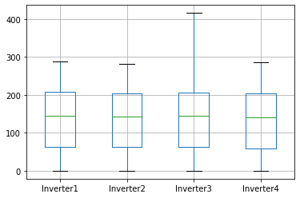

```python
newdf.boxplot( column = ['Inverter1','Inverter2','Inverter3','Inverter4' ])
```

Boxplots from each inverter with the cleaned data

```python
newdf.to_dict(orient='index')
```

[output not shown]

[output cut: 3505 more lines]

[output not shown]

Since Date is associated with all the inverters, we will orient the dictionary by index to minimize repetition.

```python
corrMatrix = newdf.corr()
print (corrMatrix)
```

```
           Inverter1  Inverter2  Inverter3  Inverter4
Inverter1   1.000000   0.996608   0.993630   0.961893
Inverter2   0.996608   1.000000   0.990665   0.963460
Inverter3   0.993630   0.990665   1.000000   0.957213
Inverter4   0.961893   0.963460   0.957213   1.000000
```

The correlation matrix below indicates that there’s a very high correlation or similarity between each and every one of the solar panel inverters. The correlation value for the diagonals is 1 because every column is identical to itself

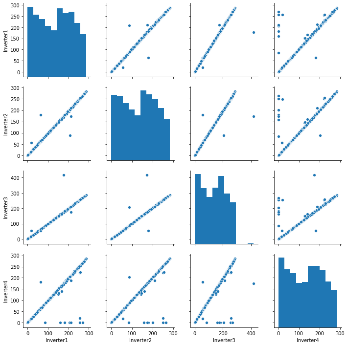

```python
import pandas as df
import numpy as np
from datetime import date
import matplotlib.pyplot as plt
import seaborn as sns
pd = df.read_csv('north-transfer-station-solar-panels.csv', index_col=0, parse_dates=True)
pd.dropna(axis = 0, how ='any', inplace=True)
Q1 = pd.quantile(0.25)
Q3 = pd.quantile(0.75)
IQR = Q3 - Q1
pd = pd[~((pd < (Q1 - 1.5 * IQR)) |(pd > (Q3 + 1.5 * IQR))).any(axis=1)]
sns.pairplot(pd)
```

The pair plot below is a visual representation of the correlation matrix.

```
array([<matplotlib.axes._subplots.AxesSubplot object at 0x0000028B9D066C08>,
      dtype=object)
```

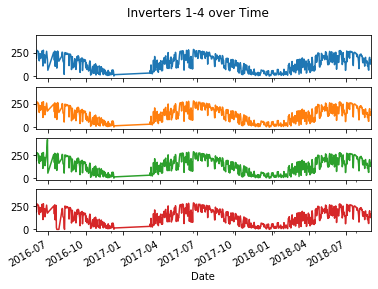

```python
import pandas as df
import numpy as np
from datetime import date
import matplotlib.pyplot as plt
pd = df.read_csv('north-transfer-station-solar-panels.csv', index_col=0, parse_dates=True)
pd.dropna(axis = 0, how ='any', inplace=True)
Q1 = pd.quantile(0.25)
Q3 = pd.quantile(0.75)
IQR = Q3 - Q1
pd = pd[~((pd < (Q1 - 1.5 * IQR)) |(pd > (Q3 + 1.5 * IQR))).any(axis=1)]
pd.plot(title = 'Inverters 1-4 over Time',legend = False, sharex='col', sharey='row', subplots=True)
```

The line plots below are designed to provide a graphical presentation of the similarities among the four inverters and seasonal variability.

```python
spr1=[]
sum1=[]
fall1=[]
win1=[]
spr2=[]
sum2=[]
fall2=[]
win2=[]
spr3=[]
sum3=[]
fall3=[]
win3=[]
spr4=[]
sum4=[]
fall4=[]
win4=[]
for i in newdf.itertuples():
    word=i.Date
    word=word.split('-')
    if word[1]=='Mar' or word[1]=='Apr' or word[1]=='May':
        spr1.append(i.Inverter1)
        spr2.append(i.Inverter2)
        spr3.append(i.Inverter3)
        spr4.append(i.Inverter4)
    if word[1]=='Jun' or word[1]=='Jul' or word[1]=='Aug':
        sum1.append(i.Inverter1)
        sum2.append(i.Inverter2)
        sum3.append(i.Inverter3)
        sum4.append(i.Inverter4)
    if word[1]=='Sep' or word[1]=='Oct' or word[1]=='Nov':
        fall1.append(i.Inverter1)
        fall2.append(i.Inverter2)
        fall3.append(i.Inverter1)
        fall4.append(i.Inverter1)
    if word[1]=='Dec' or word[1]=='Jan' or word[1]=='Feb':
        win1.append(i.Inverter1)
        win2.append(i.Inverter2)
        win3.append(i.Inverter3)
        win4.append(i.Inverter4)
```

grouping the data into seasons

```python
import scipy.stats as stats
f_value, p_value = stats.f_oneway(spr1,spr2,spr3,spr4)
print(f_value, "   ", p_value)
f_value1, p_value1 = stats.f_oneway(sum1,sum2,sum3,sum4)
print(f_value1, "   ", p_value1)
f_value2, p_value2 = stats.f_oneway(fall1,fall2,fall3,fall4)
print(f_value2, "   ", p_value2)
f_value3, p_value3 = stats.f_oneway(win1,win2,win3,win4)
print(f_value3, "   ", p_value3)
```

```
0.04639969626702745     0.9867384493880185
1.474615087786745     0.21987652581678377
0.02562335891891728     0.9944554020010785
0.005055204124114     0.9995046183626672
```

```python
print(len(spr1))
print(len(sum1))
print(len(fall1))
print(len(win1))
```

```
178
252
182
100
```

finding total number of readings in each season

```python
total=0
for i in spr1:
    total+=i
print(total/178)
total=0
for i in sum1:
    total+=i
print(total/252)
total=0
for i in fall1:
    total+=i
print(total/182)
total=0
for i in win1:
    total+=i
print(total/100)
```

```
150.25168539325838
202.86111111111114
90.95989010989005
41.06399999999999
```

calc means

```python
total=0
for i in spr2:
    total+=i
print(total/178)
total=0
for i in sum2:
    total+=i
print(total/252)
total=0
for i in fall2:
    total+=i
print(total/182)
total=0
for i in win2:
    total+=i
print(total/100)
```

```
147.73258426966294
198.6436507936506
89.53406593406596
40.602999999999994
```

calc means

```python
total=0
for i in spr3:
    total+=i
print(total/178)
total=0
for i in sum3:
    total+=i
print(total/252)
total=0
for i in fall3:
    total+=i
print(total/182)
total=0
for i in win3:
    total+=i
print(total/100)
```

```
149.40955056179777
202.66031746031754
90.95989010989005
40.596
```

calc means

```python
total=0
for i in spr4:
    total+=i
print(total/178)
total=0
for i in sum4:
    total+=i
print(total/252)
total=0
for i in fall4:
    total+=i
print(total/182)
total=0
for i in win4:
    total+=i
print(total/100)
```

```
148.69157303370787
193.5968253968253
90.95989010989005
40.69
```

calc means

|  | Inverter1 | Inverter2 | Inverter3 | Inverter4 |
| --- | --- | --- | --- | --- |
| count | 100.000000 | 100.00000 | 100.000000 | 100.000000 |
| mean | 41.064000 | 40.60300 | 40.596000 | 40.690000 |
| std | 31.279911 | 30.88821 | 31.153085 | 31.198386 |
| min | 0.300000 | 0.00000 | 0.600000 | 0.000000 |
| 25% | 17.750000 | 17.42500 | 17.525000 | 17.275000 |
| 50% | 30.850000 | 30.30000 | 30.400000 | 30.150000 |
| 75% | 58.350000 | 57.87500 | 57.700000 | 58.250000 |
| max | 157.700000 | 155.40000 | 157.000000 | 156.300000 |

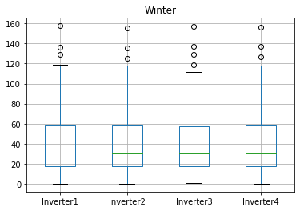

```python
import pandas as df
import numpy as np
from datetime import date
import matplotlib.pyplot as plt
import seaborn as sns
pd = df.read_csv('north-transfer-station-solar-panels.csv', index_col=0, parse_dates=True)
pd.dropna(axis = 0, how ='any', inplace=True)
Q1 = pd.quantile(0.25)
Q3 = pd.quantile(0.75)
IQR = Q3 - Q1
pd = pd[~((pd < (Q1 - 1.5 * IQR)) |(pd > (Q3 + 1.5 * IQR))).any(axis=1)]


winter1 = pd['2016-12-01':'2017-02-28']
winter2 = pd['2017-12-01': '2018-02-28']
winter= winter1.append(winter2)
#f, axes = plt.subplots(1, 2,sharex='col', sharey='row')
plt.tight_layout()
#winter1.boxplot(ax=axes[0])
#winter1.describe()
#winter2.boxplot(ax=axes[1])
#winter2.describe()
winter.boxplot()
title_boxplot = 'Winter'
plt.title( title_boxplot )
winter.describe()
```

plot boxplots and data associated with boxplots

|  | Inverter1 | Inverter2 | Inverter3 | Inverter4 |
| --- | --- | --- | --- | --- |
| count | 178.000000 | 178.000000 | 178.000000 | 178.000000 |
| mean | 150.251685 | 147.732584 | 149.409551 | 148.691573 |
| std | 66.590281 | 65.635348 | 66.482823 | 66.355726 |
| min | 20.200000 | 19.900000 | 19.300000 | 20.100000 |
| 25% | 97.900000 | 96.175000 | 97.150000 | 96.200000 |
| 50% | 152.400000 | 149.950000 | 151.900000 | 151.450000 |
| 75% | 197.850000 | 194.325000 | 197.100000 | 195.775000 |
| max | 272.800000 | 269.700000 | 272.000000 | 271.700000 |

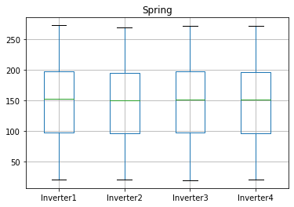

```python
import pandas as df
import numpy as np
from datetime import date
import matplotlib.pyplot as plt
import seaborn as sns
pd = df.read_csv('north-transfer-station-solar-panels.csv', index_col=0, parse_dates=True)
pd.dropna(axis = 0, how ='any', inplace=True)
Q1 = pd.quantile(0.25)
Q3 = pd.quantile(0.75)
IQR = Q3 - Q1
pd = pd[~((pd < (Q1 - 1.5 * IQR)) |(pd > (Q3 + 1.5 * IQR))).any(axis=1)]

spring1 = pd['2017-03-01': '2017-05-31']
spring2 = pd['2018-03-01': '2018-05-31']
spring = spring1.append(spring2)
#f, axes = plt.subplots(1, 3,sharex='col', sharey='row')
#plt.tight_layout()
#spring1.boxplot(ax=axes[0])
#spring2.boxplot(ax=axes[1])
spring.boxplot()
title_boxplot = 'Spring'
plt.title( title_boxplot )
spring.describe()
```

plot boxplots and data associated with boxplots

|  | Inverter1 | Inverter2 | Inverter3 | Inverter4 |
| --- | --- | --- | --- | --- |
| count | 252.000000 | 252.000000 | 252.000000 | 252.000000 |
| mean | 202.861111 | 198.643651 | 202.660317 | 193.596825 |
| std | 54.720009 | 53.170085 | 55.969230 | 63.245736 |
| min | 19.100000 | 55.400000 | 55.500000 | 0.000000 |
| 25% | 169.800000 | 165.200000 | 168.475000 | 162.150000 |
| 50% | 210.650000 | 207.150000 | 209.750000 | 206.000000 |
| 75% | 248.725000 | 243.825000 | 247.375000 | 240.500000 |
| max | 287.200000 | 282.800000 | 416.100000 | 285.400000 |

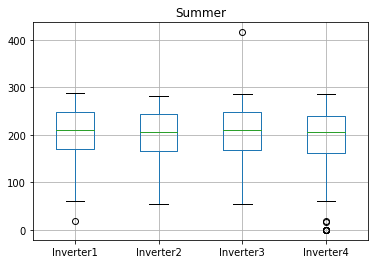

```python
import pandas as df
import numpy as np
from datetime import date
import matplotlib.pyplot as plt
import seaborn as sns
pd = df.read_csv('north-transfer-station-solar-panels.csv', index_col=0, parse_dates=True)
pd.dropna(axis = 0, how ='any', inplace=True)
Q1 = pd.quantile(0.25)
Q3 = pd.quantile(0.75)
IQR = Q3 - Q1
pd = pd[~((pd < (Q1 - 1.5 * IQR)) |(pd > (Q3 + 1.5 * IQR))).any(axis=1)]


summer1 = pd['2016-06-01': '2016-08-31']
summer2 = pd['2017-06-01': '2017-08-31']
summer3 = pd['2018-06-01': '2018-08-31']
summera = summer1.append(summer2)
summer = summera.append(summer3)
#f, axes = plt.subplots(1, 3,sharex='col', sharey='row')
plt.tight_layout()
#summer1.boxplot(ax=axes[0])
#summer1.describe()
#summer2.boxplot(ax=axes[1])
#summer2.describe()
#summer3.boxplot(ax=axes[2])
#summer3.describe()
summer.boxplot()
title_boxplot = 'Summer'
plt.title( title_boxplot )
summer.describe()
```

plot boxplots and data associated with boxplots

|  | Inverter1 | Inverter2 | Inverter3 | Inverter4 |
| --- | --- | --- | --- | --- |
| count | 182.000000 | 182.000000 | 182.000000 | 182.000000 |
| mean | 90.959890 | 89.534066 | 90.350549 | 89.873077 |
| std | 60.318105 | 59.373238 | 60.143023 | 59.889218 |
| min | 5.100000 | 5.400000 | 5.300000 | 5.100000 |
| 25% | 37.525000 | 36.550000 | 36.900000 | 36.600000 |
| 50% | 85.300000 | 83.550000 | 84.600000 | 84.000000 |
| 75% | 138.050000 | 135.650000 | 137.250000 | 136.550000 |
| max | 221.200000 | 216.400000 | 219.900000 | 218.400000 |

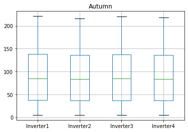

```python
import pandas as df
import numpy as np
from datetime import date
import matplotlib.pyplot as plt
import seaborn as sns
from pylab import plot, show, savefig, xlim, figure, ylim, legend, boxplot, setp, axes
pd = df.read_csv('north-transfer-station-solar-panels.csv', index_col=0, parse_dates=True)
pd.dropna(axis = 0, how ='any', inplace=True)
Q1 = pd.quantile(0.25)
Q3 = pd.quantile(0.75)
IQR = Q3 - Q1
pd = pd[~((pd < (Q1 - 1.5 * IQR)) |(pd > (Q3 + 1.5 * IQR))).any(axis=1)]

autumn1 = pd['2016-09-01': '2016-11-30']
autumn2 = pd['2017-09-01': '2017-11-30']
autumn = autumn1.append(autumn2)
#f, axes = plt.subplots(1, 2,sharex='col', sharey='row')
plt.tight_layout()
#autumn1.boxplot(ax=axes[0])
#autumn1.describe()
#autumn2.boxplot(ax=axes[1])
#autumn2.describe()
autumn.boxplot()
title_boxplot = 'Autumn'
plt.title( title_boxplot )
autumn.describe()
```

plot boxplots and data associated with boxplots